# HW3

Volodymyr Kotov,Serhii Marinchenko, Milan Vannik

2023-02-04

```r
library(tidyverse)
library(readxl)
library(xts)
library(tseries)
library(foreign)
library(tsibble)
library(tsibbledata)
library(feasts)
library(fable)
library(urca)
library(dplyr)
library(astsa)
library(ggplot2)
library(forecast)
library(lubridate)
library(zoo)
library(fGarch)
library(astsa)
library(rugarch)
library(stringr)
library(usefun)
library(erer)
```

## Part I. ADF test

```r
setwd("~/Desktop/KSE/Econometrics III")
df <- read_excel("quarterly.xls") %>%
  select(DATE, Tbill, r5) %>%
  mutate(
    st = r5 - Tbill,
    DATE = str_replace(DATE, pattern="Q", replacement = "-0") %>%
      as_date(format = "%Y-%m")
    )
```

#### Select the model with AIC/BIC

```r
for (i in 1:12) {
  print(paste("Lag # ", i))
  print((paste("AIC = ", as.character(ur.df2(df$st, lags = i, type = "trend")$aic))))
  print((paste("BIC = ", as.character(ur.df2(df$st, lags = i, type = "trend")$bic))))
  print_empty_line()
}
```

```
## [1] "Lag #  1"
## [1] "AIC =  296.021073005221"
## [1] "BIC =  312.804004378581"
##
## [1] "Lag #  2"
## [1] "AIC =  295.180086747522"
## [1] "BIC =  315.319604395555"
##
## [1] "Lag #  3"
## [1] "AIC =  288.706257765035"
## [1] "BIC =  312.202361687739"
##
## [1] "Lag #  4"
## [1] "AIC =  290.201091620475"
## [1] "BIC =  317.053781817851"
```

[output cut: 32 more lines]

#### Select the model with GTS

```r
for (i in 12:8) {
  print(ur.df2(df$st, lags = i, type = "trend")$testreg$coefficients)
   print_empty_line()
}
```

```
##                   Estimate   Std. Error     t value     Pr(>|t|)
## (Intercept)   0.2439715592 0.0901141395  2.70736158 7.420986e-03
## z.lag.1      -0.2758371550 0.0625809284 -4.40768717 1.772546e-05
## tt            0.0008148084 0.0006137413  1.32760871 1.859522e-01
## z.diff.lag1   0.3640256631 0.0812694513  4.47924352 1.312646e-05
## z.diff.lag2  -0.0451755176 0.0811493182 -0.55669621 5.784115e-01
## z.diff.lag3   0.3101682540 0.0801398018  3.87033967 1.508030e-04
## z.diff.lag4   0.0082138688 0.0822275892  0.09989188 9.205389e-01
## z.diff.lag5   0.1893183185 0.0821228266  2.30530690 2.226503e-02
## z.diff.lag6  -0.0276277152 0.0809664012 -0.34122444 7.333240e-01
## z.diff.lag7   0.0046516719 0.0777349840  0.05984013 9.523479e-01
## z.diff.lag8   0.2226601092 0.0775651618  2.87062006 4.576894e-03
## z.diff.lag9   0.0960413527 0.0766346939  1.25323594 2.117100e-01
## z.diff.lag10  0.0969224974 0.0771528465  1.25624007 2.106216e-01
## z.diff.lag11 -0.0932278916 0.0739802490 -1.26017272 2.092029e-01
## z.diff.lag12  0.1039258786 0.0738575129  1.40711316 1.610808e-01
##
##                   Estimate   Std. Error     t value     Pr(>|t|)
## (Intercept)   0.2244922656 0.0881467008  2.54680281 1.168133e-02
## z.lag.1      -0.2500253514 0.0598422217 -4.17807602 4.517338e-05
## tt            0.0007206608 0.0006071587  1.18693981 2.367651e-01
## z.diff.lag1   0.3291541162 0.0774870111  4.24786182 3.407181e-05
## z.diff.lag2  -0.0643344669 0.0799999951 -0.80418088 4.223191e-01
## z.diff.lag3   0.2938799033 0.0793261969  3.70470179 2.789481e-04
## z.diff.lag4   0.0018702040 0.0821172184  0.02277481 9.818543e-01
## z.diff.lag5   0.1623210400 0.0799123131  2.03123941 4.365380e-02
## z.diff.lag6  -0.0594174476 0.0776088510 -0.76560143 4.448839e-01
## z.diff.lag7  -0.0044417999 0.0774699596 -0.05733577 9.543393e-01
## z.diff.lag8   0.1959710161 0.0752810249  2.60319272 9.981090e-03
## z.diff.lag9   0.1007728328 0.0765543978  1.31635589 1.896744e-01
## z.diff.lag10  0.0649379779 0.0738110950  0.87978613 3.801104e-01
## z.diff.lag11 -0.0844667330 0.0736023317 -1.14760947 2.526038e-01
##
##                   Estimate  Std. Error    t value     Pr(>|t|)
## (Intercept)   0.2411354813 0.085777977  2.8111584 5.459605e-03
## z.lag.1      -0.2730724182 0.056329372 -4.8477803 2.607260e-06
## tt            0.0008111965 0.000598956  1.3543507 1.772501e-01
## z.diff.lag1   0.3473203087 0.075751203  4.5850138 8.265740e-06
## z.diff.lag2  -0.0511643276 0.079104924 -0.6467907 5.185563e-01
## z.diff.lag3   0.3013520870 0.078951446  3.8169293 1.833000e-04
```

[output cut: 19 more lines]

```
## z.diff.lag8  0.1757800136 0.0714609479  2.45980523 1.479528e-02
## z.diff.lag9  0.1324504927 0.0721891063  1.83477119 6.810329e-02
##
##                  Estimate   Std. Error     t value     Pr(>|t|)
## (Intercept)  0.1992522717 0.0821231437  2.42626211 1.617946e-02
## z.lag.1     -0.2283269807 0.0504310076 -4.52751178 1.045711e-05
## tt           0.0006944008 0.0005850534  1.18690160 2.367329e-01
## z.diff.lag1  0.3350912289 0.0750750644  4.46341580 1.373215e-05
## z.diff.lag2 -0.0890205321 0.0767092864 -1.16049225 2.472894e-01
## z.diff.lag3  0.2479751482 0.0739760600  3.35209996 9.659116e-04
## z.diff.lag4 -0.0042222413 0.0759322243 -0.05560539 9.557140e-01
## z.diff.lag5  0.1554743419 0.0739858240  2.10140718 3.690994e-02
## z.diff.lag6 -0.0662747819 0.0748732831 -0.88515929 3.771779e-01
## z.diff.lag7 -0.0214943055 0.0714943327 -0.30064349 7.640117e-01
## z.diff.lag8  0.1868831279 0.0712245894  2.62385686 9.393041e-03
```

All models with lag order higher than 8 have insignificant last coefficient (p-value > 0.01).  
=> include 8 lags in ADF test.

#### Does the Lag order matter?

```r
for (i in 1:9) {
  print(paste("Lag # ", i))
  print(ur.df2(df$st, lags = i, type = "trend"))
  print_empty_line()
  print_empty_line()
}
```

```
## [1] "Lag #  1"
##
## === Test statistics =========
##                tau3     phi2     phi3
## statistic -4.816962 7.740493 11.60596
##
## === Test critical values ====
##       1pct  5pct 10pct
## tau3 -3.99 -3.43 -3.13
## phi2  6.22  4.75  4.07
## phi3  8.43  6.49  5.47
##
## === Combined output =========
## [1] "-4.82 [1]***"
##
##
## [1] "Lag #  2"
##
## === Test statistics =========
##                tau3     phi2     phi3
## statistic -4.054245 5.489596 8.230596
##
## === Test critical values ====
##       1pct  5pct 10pct
## tau3 -3.99 -3.43 -3.13
## phi2  6.22  4.75  4.07
## phi3  8.43  6.49  5.47
##
## === Combined output =========
## [1] "-4.05 [2]***"
##
##
## [1] "Lag #  3"
##
## === Test statistics =========
##                tau3     phi2     phi3
## statistic -4.734299 7.478205 11.20966
##
## === Test critical values ====
##       1pct  5pct 10pct
```

[output cut: 87 more lines]

```
##
## [1] "Lag #  9"
##
## === Test statistics =========
##                tau3     phi2    phi3
## statistic -4.882283 7.955777 11.9333
##
## === Test critical values ====
##       1pct  5pct 10pct
## tau3 -3.99 -3.43 -3.13
## phi2  6.22  4.75  4.07
## phi3  8.43  6.49  5.47
##
## === Combined output =========
## [1] "-4.88 [9]***"
```

With the 5% significance, test statistics are always bigger than corresponding critical values. So, the # of lags in the model does not matter in this case because H0 is rejected with any number of lags.

## Part II. Forecast Evaluation

#### From previous HW

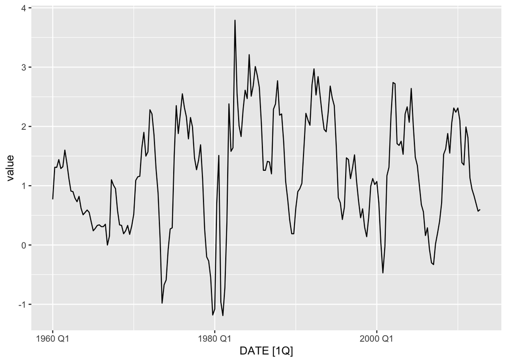

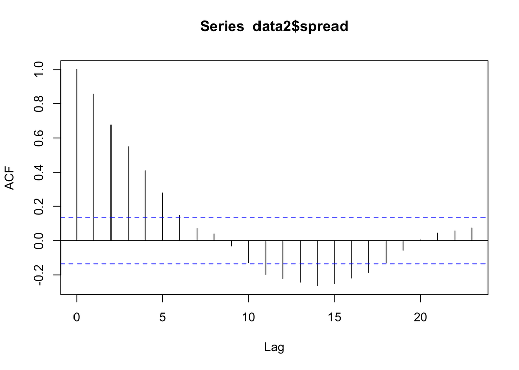

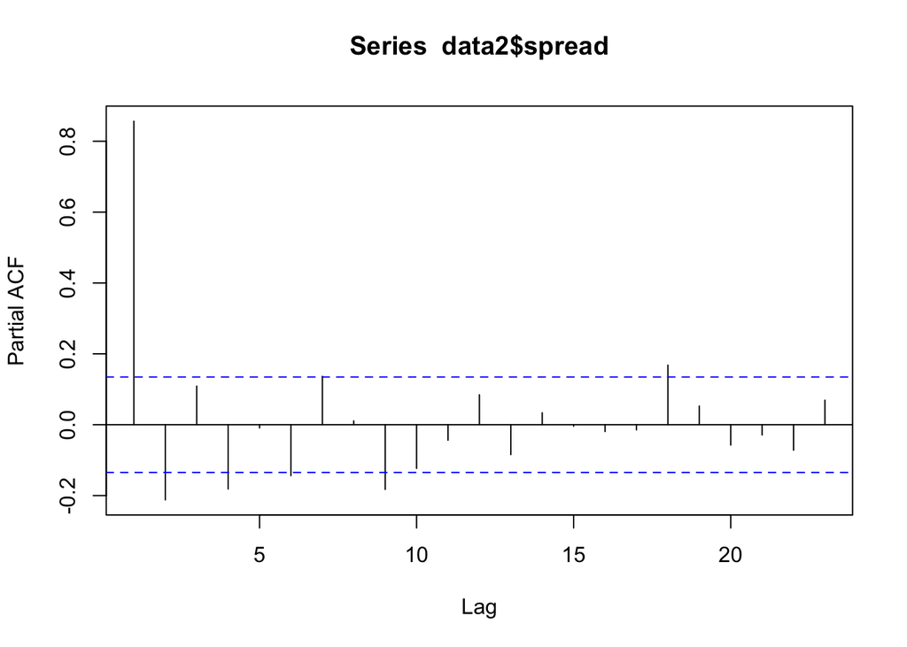

```
##
## Call:
## arima(x = data2_test$spread, order = c(2, 0, 7), fixed = c(NA, NA, NA, 0, 0,
##     0, 0, 0, NA, NA))
##
## Coefficients:
##          ar1     ar2     ma1  ma2  ma3  ma4  ma5  ma6      ma7  intercept
##       0.3322  0.4013  0.7878    0    0    0    0    0  -0.1360     1.1691
## s.e.  0.1341  0.1248  0.1012    0    0    0    0    0   0.0505     0.2242
##
## sigma^2 estimated as 0.2225:  log likelihood = -109.11,  aic = 230.21
##
## Training set error measures:
##                       ME      RMSE       MAE  MPE MAPE      MASE         ACF1
## Training set 0.002990406 0.4716741 0.3347651 -Inf  Inf 0.9373424 -0.008637673
```

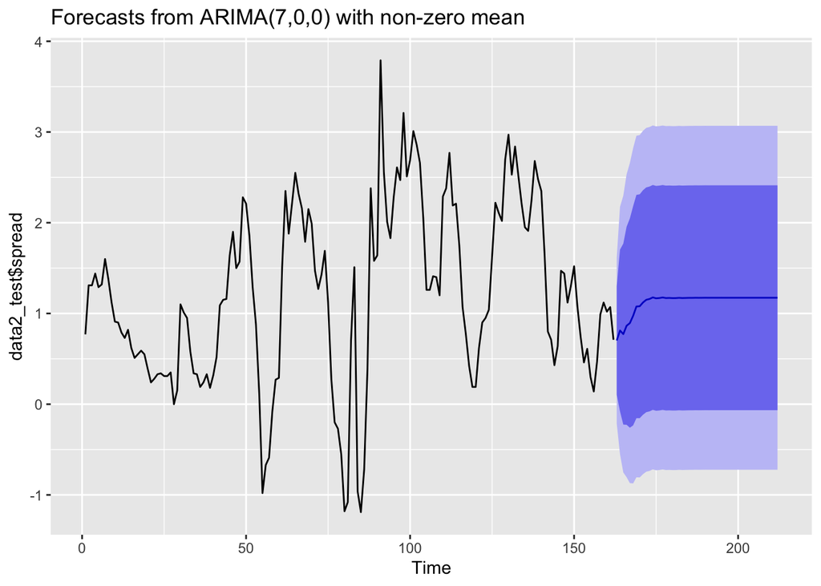

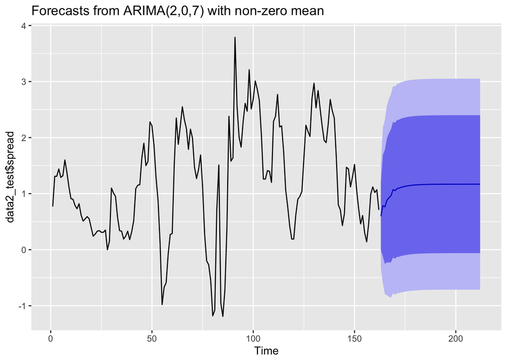

```
##
## Call:
## lm(formula = data2_check$spread ~ pred_ar7$mean)
##
## Residuals:
##     Min      1Q  Median      3Q     Max
## -1.6702 -0.6516  0.1641  0.6743  1.5810
##
## Coefficients:
##               Estimate Std. Error t value Pr(>|t|)
## (Intercept)     -0.868      1.227  -0.708   0.4826
## pred_ar7$mean    1.883      1.083   1.738   0.0886 .
## ---
## Signif. codes:  0 '***' 0.001 '**' 0.01 '*' 0.05 '.' 0.1 ' ' 1
##
## Residual standard error: 0.8661 on 48 degrees of freedom
## Multiple R-squared:  0.0592, Adjusted R-squared:  0.0396
## F-statistic: 3.021 on 1 and 48 DF,  p-value: 0.08863
```

```
##
## Call:
## lm(formula = data2_check$spread ~ pred_arma2_7$mean)
##
## Residuals:
##     Min      1Q  Median      3Q     Max
## -1.6704 -0.6899  0.1731  0.6895  1.5647
##
## Coefficients:
##                   Estimate Std. Error t value Pr(>|t|)
## (Intercept)        -0.5682     1.1548  -0.492    0.625
## pred_arma2_7$mean   1.6359     1.0311   1.587    0.119
##
## Residual standard error: 0.8704 on 48 degrees of freedom
## Multiple R-squared:  0.04983,    Adjusted R-squared:  0.03003
## F-statistic: 2.517 on 1 and 48 DF,  p-value: 0.1192
```

#### Calculate bias

Procedure:

Find the volatility by subtracting forecasted value from the real value, build a regression, where y = volatility from the previous point and, x = forecasted value. Evaluate the regression. If B0 is insignificant or equal to 0 and B1 is insignificant or equal to 1, then there is no bias

```r
volat_ar7 <- data2_check$spread - pred_ar7$mean
mean(volat_ar7)
```

```
## [1] 0.1267391
```

```r
lm_ar7 <- lm(volat_ar7 ~ pred_ar7$mean)
summary(lm_ar7) #there is no bias in the model ar7
```

```
##
## Call:
## lm(formula = volat_ar7 ~ pred_ar7$mean)
##
## Residuals:
##     Min      1Q  Median      3Q     Max
## -1.6702 -0.6516  0.1641  0.6743  1.5810
##
## Coefficients:
##               Estimate Std. Error t value Pr(>|t|)
## (Intercept)    -0.8680     1.2268  -0.708    0.483
## pred_ar7$mean   0.8829     1.0834   0.815    0.419
##
## Residual standard error: 0.8661 on 48 degrees of freedom
## Multiple R-squared:  0.01365,    Adjusted R-squared:  -0.006901
## F-statistic: 0.6642 on 1 and 48 DF,  p-value: 0.4191
```

```r
volat_arma2_7 <- data2_check$spread - pred_arma2_7$mean
lm_arma2_7 <- lm(volat_arma2_7 ~ pred_arma2_7$mean)
summary(lm_arma2_7) #there is no bias in the model arma2_7
```

```
##
## Call:
## lm(formula = volat_arma2_7 ~ pred_arma2_7$mean)
##
## Residuals:
##     Min      1Q  Median      3Q     Max
## -1.6704 -0.6899  0.1731  0.6895  1.5647
##
## Coefficients:
##                   Estimate Std. Error t value Pr(>|t|)
## (Intercept)        -0.5682     1.1548  -0.492    0.625
## pred_arma2_7$mean   0.6359     1.0311   0.617    0.540
##
## Residual standard error: 0.8704 on 48 degrees of freedom
## Multiple R-squared:  0.007861,   Adjusted R-squared:  -0.01281
## F-statistic: 0.3803 on 1 and 48 DF,  p-value: 0.5403
```

There is no bias in the models ar7 and arma2_7.

#### Calculate MSPE and GN statistics

```r
z <- volat_ar7 - volat_arma2_7
x <- volat_ar7 + volat_arma2_7
r <- cor(x,z)
gn_test <- r/(((1-(r)^2)/(length(volat_ar7)-1))^(1/2))
print(paste("GN statistics =", as.character(gn_test)))
```

```
## [1] "GN statistics = -0.611709124175802"
```

```r
#for ar7:
MSPE_ar7 <- mean((volat_ar7)^2)
print(paste("MSPE for AR(7) =", as.character(MSPE_ar7)))
```

```
## [1] "MSPE for AR(7) = 0.746195485809337"
```

```r
#for arma(2,(1,7))
MSPE_arima2_7 <- mean((volat_arma2_7)^2)
print(paste("MSPE for ARIMA(2,0,(1,7)) =", as.character(MSPE_arima2_7)))
```

```
## [1] "MSPE for ARIMA(2,0,(1,7)) = 0.752675413647734"
```

#### Calculate RMSE, MAE and MAPE

```r
#RMSE for ar7:
RMSE_ar7 <- (sum((volat_ar7)^2/length((volat_ar7)))^(1/2))
print(paste("RMSE for AR(7) =", as.character(RMSE_ar7)))
```

```
## [1] "RMSE for AR(7) = 0.863826073818877"
```

```r
#for arma(2,(1,7)):
RMSE_arima2_7 <- (sum((volat_arma2_7)^2/length((volat_arma2_7)))^(1/2))
print(paste("RMSE for ARIMA(2,0,(1,7)) =", as.character(RMSE_arima2_7)))
```

```
## [1] "RMSE for ARIMA(2,0,(1,7)) = 0.867568679499055"
```

```r
#MAE and MAPE:

#Mean absolute error (MAE) and mean absolute percentage error (MAPE):

#MAE for ar7:
MAE_ar7 <- sum(abs(volat_ar7))/length(volat_ar7)
print(paste("MAE for AR(7) =", as.character(MAE_ar7)))
```

```
## [1] "MAE for AR(7) = 0.756462252409613"
```

```r
#for arma(2,(1,7)):
MAE_arima2_7 <- sum(abs(volat_arma2_7))/length(volat_arma2_7)
print(paste("MAE for ARIMA(2,0,(1,7)) =", as.character(MAE_arima2_7)))
```

```
## [1] "MAE for ARIMA(2,0,(1,7)) = 0.759559610118861"
```

```r
#MAPE for ar7:
MAPE_ar7 <- sum(abs(data2_check$spread - pred_ar7$mean/data2_check$spread))/length(data2_check$spread)
print(paste("MAPE for AR(7) =", as.character(MAPE_ar7)))
```

```
## [1] "MAPE for AR(7) = 4.0787030706585"
```

```r
#for arma(2,(1,7)):
MAPE_arima2_7 <- sum(abs(data2_check$spread - pred_arma2_7$mean/data2_check$spread))/length(data2_check$spread)
print(paste("MAPE for ARIMA(2,0,(1,7)) =", as.character(MAPE_arima2_7)))
```

```
## [1] "MAPE for ARIMA(2,0,(1,7)) = 4.0084837431281"
```

## GARCH (50%)

```r
data1 <- read_xls("quarterly.xls")

data2 <- data1 %>%
  select(., c("DATE","r5","Tbill")) %>%
  mutate(DATE = yearquarter(data1$DATE))

data2$spread <- data1$r5 - data1$Tbill
data2 <- as_tsibble(data2, index = "DATE")

arima2_7 <- arima(data2$spread, order=c(2,0,7), fixed = c(NA,NA,NA,0,0,0,0,0,NA,NA))
summary(arima2_7)
```

```
##
## Call:
## arima(x = data2$spread, order = c(2, 0, 7), fixed = c(NA, NA, NA, 0, 0, 0, 0,
##     0, NA, NA))
##
## Coefficients:
##          ar1     ar2     ma1  ma2  ma3  ma4  ma5  ma6      ma7  intercept
##       0.3381  0.4006  0.7846    0    0    0    0    0  -0.1390     1.1922
## s.e.  0.1229  0.1160  0.0913    0    0    0    0    0   0.0396     0.1935
##
## sigma^2 estimated as 0.208:  log likelihood = -135.38,  aic = 282.76
##
## Training set error measures:
##                       ME     RMSE       MAE  MPE MAPE      MASE        ACF1
## Training set 0.002430835 0.456113 0.3293779 -Inf  Inf 0.9317434 0.005730001
```

equation form:  
y[t] = 1.1922 + 0.3381*y[t-1] + 0.4006*y[t-2] + e[t] + 0.7846*e[t-1] - 0.1390*e[t-7]

```r
resid_arima2_7 <- residuals(arima2_7)
log(nrow(data2))
```

```
## [1] 5.356586
```

```r
FinTS::ArchTest(resid_arima2_7, lag=5)
```

```
##
##  ARCH LM-test; Null hypothesis: no ARCH effects
##
## data:  resid_arima2_7
## Chi-squared = 30.369, df = 5, p-value = 1.248e-05
```

There are ARCH effects present. Lets deal with it.

We will do our estimations based on data and indicate the proper arma inside of the garch model specifics.

#### —————————————–

Lets set specifics of our garch(1,1) model

```r
garch1_1Spec = ugarchspec(variance.model=list(model="sGARCH", garchOrder=c(1,1)),
              mean.model=list(armaOrder=c(2,7),
              include.mean=T),
              distribution.model="sstd",
              fixed.pars=list(ma2=0, ma3=0, ma4=0, ma5=0, ma6=0))

garch1_1Fit <- ugarchfit(spec = garch1_1Spec, data = data2$spread)
print(garch1_1Fit)
```

```
##
## *---------------------------------*
## *          GARCH Model Fit        *
## *---------------------------------*
##
## Conditional Variance Dynamics
## -----------------------------------
## GARCH Model  : sGARCH(1,1)
## Mean Model   : ARFIMA(2,0,7)
## Distribution : sstd
##
## Optimal Parameters
## ------------------------------------
##         Estimate  Std. Error  t value Pr(>|t|)
## mu      1.039514    0.172068   6.0413 0.000000
## ar1     0.649860    0.227571   2.8556 0.004295
## ar2     0.182686    0.214346   0.8523 0.394049
## ma1     0.523546    0.210007   2.4930 0.012667
## ma2     0.000000          NA       NA       NA
## ma3     0.000000          NA       NA       NA
## ma4     0.000000          NA       NA       NA
## ma5     0.000000          NA       NA       NA
## ma6     0.000000          NA       NA       NA
## ma7    -0.086772    0.051726  -1.6775 0.093438
## omega   0.016423    0.013815   1.1888 0.234504
## alpha1  0.238231    0.131934   1.8057 0.070968
## beta1   0.760769    0.097632   7.7922 0.000000
## skew    1.177458    0.098584  11.9437 0.000000
## shape   3.517910    1.507691   2.3333 0.019632
##
## Robust Standard Errors:
##         Estimate  Std. Error  t value Pr(>|t|)
## mu      1.039514    0.197196  5.27148 0.000000
## ar1     0.649860    0.290889  2.23405 0.025480
## ar2     0.182686    0.281692  0.64853 0.516641
## ma1     0.523546    0.275737  1.89872 0.057602
## ma2     0.000000          NA       NA       NA
## ma3     0.000000          NA       NA       NA
## ma4     0.000000          NA       NA       NA
## ma5     0.000000          NA       NA       NA
```

[output cut: 65 more lines]

```
## Negative Sign Bias  0.4598 0.64615
## Positive Sign Bias  1.7360 0.08406   *
## Joint Effect        5.8031 0.12159
##
##
## Adjusted Pearson Goodness-of-Fit Test:
## ------------------------------------
##   group statistic p-value(g-1)
## 1    20     19.13       0.4484
## 2    30     22.91       0.7808
## 3    40     35.92       0.6109
## 4    50     46.49       0.5754
##
##
## Elapsed time : 0.1410251
```

#### ………………..

#### Tests for GARCH(1,1)

#### ………………..

ARCH test. Lags that were used: 3,5,7. Result: on all of the lags above, the p-value is to high, so we cannot reject H0 that states that we have no ARCH effect

AIC: 1.1028 BIC: 1.2611

#### —————————————–

Lets set specifics of our garch(1,2) model

```r
garch1_2Spec = ugarchspec(variance.model=list(model="sGARCH", garchOrder=c(1,2)),
                          mean.model=list(armaOrder=c(2,7),
                                          include.mean=T),
                          distribution.model="sstd",
                          fixed.pars=list(ma2=0, ma3=0, ma4=0, ma5=0, ma6=0))

garch1_2Fit <- ugarchfit(spec = garch1_2Spec, data = data2$spread)
print(garch1_2Fit)
```

```
##
## *---------------------------------*
## *          GARCH Model Fit        *
## *---------------------------------*
##
## Conditional Variance Dynamics
## -----------------------------------
## GARCH Model  : sGARCH(1,2)
## Mean Model   : ARFIMA(2,0,7)
## Distribution : sstd
##
## Optimal Parameters
## ------------------------------------
##         Estimate  Std. Error  t value Pr(>|t|)
## mu      1.039514    0.171636  6.05648 0.000000
## ar1     0.649856    0.214557  3.02883 0.002455
## ar2     0.182689    0.203879  0.89607 0.370217
## ma1     0.523550    0.195517  2.67777 0.007411
## ma2     0.000000          NA       NA       NA
## ma3     0.000000          NA       NA       NA
## ma4     0.000000          NA       NA       NA
## ma5     0.000000          NA       NA       NA
## ma6     0.000000          NA       NA       NA
## ma7    -0.086771    0.051710 -1.67802 0.093344
## omega   0.016423    0.009097  1.80538 0.071016
## alpha1  0.238230    0.050728  4.69619 0.000003
## beta1   0.760770    0.703201  1.08187 0.279311
## beta2   0.000000    0.610900  0.00000 1.000000
## skew    1.177459    0.098074 12.00581 0.000000
## shape   3.517945    1.382724  2.54421 0.010952
##
## Robust Standard Errors:
##         Estimate  Std. Error  t value Pr(>|t|)
## mu      1.039514    0.197399  5.26605 0.000000
## ar1     0.649856    0.274185  2.37013 0.017782
## ar2     0.182689    0.267114  0.68394 0.494013
## ma1     0.523550    0.257186  2.03568 0.041782
## ma2     0.000000          NA       NA       NA
## ma3     0.000000          NA       NA       NA
## ma4     0.000000          NA       NA       NA
```

[output cut: 68 more lines]

```
## Negative Sign Bias  0.4598 0.64615
## Positive Sign Bias  1.7360 0.08405   *
## Joint Effect        5.8031 0.12159
##
##
## Adjusted Pearson Goodness-of-Fit Test:
## ------------------------------------
##   group statistic p-value(g-1)
## 1    20     19.13       0.4484
## 2    30     22.91       0.7808
## 3    40     35.92       0.6109
## 4    50     46.49       0.5754
##
##
## Elapsed time : 0.1134861
```

As we can see, differences, that we have are quite low.

#### ………………..

#### Tests for GARCH(1,2)

#### ………………..

Ljung-Box Test on Standardized Squared Residuals. Lags that were used: 1,8,14.  
Result: because of high enough p-value, we can say that on all lags (on 8 on 7% s.l.)  
Our squared residuals are iid.

Ljung-Box Test on Standardized Residuals. Lags that were used: 1,26,44. Result: an all lags above our p-value is to small <- no iid.

ARCH test. Lags that were used: 4,6,8. Result: high p-value = no ARCH effect anymore.

AIC: 1.1122 BIC: 1.2864

#### —————————————–

Lets set specifics of our garch(2,1) model

```r
garch2_1Spec = ugarchspec(variance.model=list(model="sGARCH", garchOrder=c(2,1)),
                          mean.model=list(armaOrder=c(2,7),
                                          include.mean=T),
                          distribution.model="sstd",
                          fixed.pars=list(ma2=0, ma3=0, ma4=0, ma5=0, ma6=0))

garch2_1Fit <- ugarchfit(spec = garch2_1Spec, data = data2$spread)
print(garch2_1Fit)
```

```
##
## *---------------------------------*
## *          GARCH Model Fit        *
## *---------------------------------*
##
## Conditional Variance Dynamics
## -----------------------------------
## GARCH Model  : sGARCH(2,1)
## Mean Model   : ARFIMA(2,0,7)
## Distribution : sstd
##
## Optimal Parameters
## ------------------------------------
##         Estimate  Std. Error    t value Pr(>|t|)
## mu       0.98129    0.018772   52.27357  0.00000
## ar1      0.27698    0.048563    5.70353  0.00000
## ar2      0.53004    0.051124   10.36762  0.00000
## ma1      0.69680    0.001832  380.31046  0.00000
## ma2      0.00000          NA         NA       NA
## ma3      0.00000          NA         NA       NA
## ma4      0.00000          NA         NA       NA
## ma5      0.00000          NA         NA       NA
## ma6      0.00000          NA         NA       NA
## ma7     -0.47614    0.001856 -256.60543  0.00000
## omega    0.01143    0.010556    1.08274  0.27892
## alpha1   0.00000    0.267375    0.00000  1.00000
## alpha2   0.27777    0.233206    1.19110  0.23361
## beta1    0.70298    0.073729    9.53470  0.00000
## skew     0.83705    0.084474    9.90890  0.00000
## shape   59.86827  321.288350    0.18634  0.85218
##
## Robust Standard Errors:
##         Estimate  Std. Error     t value Pr(>|t|)
## mu       0.98129    0.012124   80.939115  0.00000
## ar1      0.27698    0.043350    6.389341  0.00000
## ar2      0.53004    0.047270   11.212841  0.00000
## ma1      0.69680    0.001422  489.980935  0.00000
## ma2      0.00000          NA          NA       NA
## ma3      0.00000          NA          NA       NA
## ma4      0.00000          NA          NA       NA
```

[output cut: 68 more lines]

```
## Negative Sign Bias  0.6764 0.4995
## Positive Sign Bias  1.3819 0.1685
## Joint Effect        3.0879 0.3783
##
##
## Adjusted Pearson Goodness-of-Fit Test:
## ------------------------------------
##   group statistic p-value(g-1)
## 1    20     21.02       0.3358
## 2    30     29.42       0.4436
## 3    40     45.36       0.2240
## 4    50     53.09       0.3193
##
##
## Elapsed time : 0.267045
```

#### ………………..

#### Tests for GARCH(2,1)

#### ………………..

Ljung-Box Test on Standardized Squared Residuals. Lags that were used: 1,8,14.  
Result: it is iid only on the first lag. On the next lags, it is iid only on 7% c.l.

Ljung-Box Test on Standardized Residuals. Lags that were used: 1,26,44.  
Result: it is iid only on the first lag. No iid on other lags.

ARCH test lags that were used: 4,6,8.  
Result: ion all lags there is still ARCH effect present.

AIC: 1.3656 BIC: 1.5398

#### —————————————–

lets set specifics of our arch(7) model

```r
arch7Spec = ugarchspec(variance.model=list(model="sGARCH", garchOrder=c(7,0)),
                          mean.model=list(armaOrder=c(2,7),
                                          include.mean=T),
                          distribution.model="sstd",
                          fixed.pars=list(ma2=0, ma3=0, ma4=0, ma5=0, ma6=0))

arch7Fit <- ugarchfit(spec = arch7Spec, data = data2$spread)
print(arch7Fit)
```

```
##
## *---------------------------------*
## *          GARCH Model Fit        *
## *---------------------------------*
##
## Conditional Variance Dynamics
## -----------------------------------
## GARCH Model  : sGARCH(7,0)
## Mean Model   : ARFIMA(2,0,7)
## Distribution : sstd
##
## Optimal Parameters
## ------------------------------------
##         Estimate  Std. Error   t value Pr(>|t|)
## mu       0.94885    0.136713  6.940432 0.000000
## ar1      0.33439    0.096986  3.447781 0.000565
## ar2      0.47077    0.099460  4.733299 0.000002
## ma1      0.82403    0.070021 11.768347 0.000000
## ma2      0.00000          NA        NA       NA
## ma3      0.00000          NA        NA       NA
## ma4      0.00000          NA        NA       NA
## ma5      0.00000          NA        NA       NA
## ma6      0.00000          NA        NA       NA
## ma7     -0.12745    0.019205 -6.636036 0.000000
## omega    0.03210    0.016897  1.899734 0.057468
## alpha1   0.00000    0.114120  0.000001 0.999999
## alpha2   0.21907    0.072858  3.006839 0.002640
## alpha3   0.14249    0.102625  1.388409 0.165012
## alpha4   0.14608    0.066178  2.207380 0.027288
## alpha5   0.12255    0.091081  1.345478 0.178471
## alpha6   0.00000    0.104220  0.000000 1.000000
## alpha7   0.29575    0.177764  1.663752 0.096162
## skew     1.08719    0.089532 12.143043 0.000000
## shape   10.10894   15.165064  0.666594 0.505032
##
## Robust Standard Errors:
##         Estimate  Std. Error  t value Pr(>|t|)
## mu       0.94885    0.220840  4.29653 0.000017
## ar1      0.33439    0.123845  2.70005 0.006933
## ar2      0.47077    0.135721  3.46867 0.000523
```

[output cut: 80 more lines]

```
## Negative Sign Bias  0.5725 0.5676
## Positive Sign Bias  1.1237 0.2624
## Joint Effect        2.0283 0.5665
##
##
## Adjusted Pearson Goodness-of-Fit Test:
## ------------------------------------
##   group statistic p-value(g-1)
## 1    20     10.64       0.9353
## 2    30     31.40       0.3470
## 3    40     32.53       0.7584
## 4    50     44.60       0.6518
##
##
## Elapsed time : 0.2275739
```

#### ………………..

#### Tests for ARCH(7)

#### ………………..

Ljung-Box Test on Standardized Squared Residuals. Lags that were used: 1,20,34.  
Result: on all lags it is iid.

Ljung-Box Test on Standardized Residuals. Lags that were used: it is iid only on the first lag. Result: 1,26,44.

ARCH test. Lags that were used: 8,10,12.  
Result: on all lags there is no arch effect.

AIC: 1.1044 BIC: 1.3419

#### —————————————–

Lets set specifics of our arch(2) model

```r
arch2Spec = ugarchspec(variance.model=list(model="sGARCH", garchOrder=c(2,0)),
                       mean.model=list(armaOrder=c(2,7),
                                       include.mean=T),
                       distribution.model="sstd",
                       fixed.pars=list(ma2=0, ma3=0, ma4=0, ma5=0, ma6=0))

arch2Fit <- ugarchfit(spec = arch2Spec, data = data2$spread)
print(arch2Fit)
```

```
##
## *---------------------------------*
## *          GARCH Model Fit        *
## *---------------------------------*
##
## Conditional Variance Dynamics
## -----------------------------------
## GARCH Model  : sGARCH(2,0)
## Mean Model   : ARFIMA(2,0,7)
## Distribution : sstd
##
## Optimal Parameters
## ------------------------------------
##         Estimate  Std. Error  t value Pr(>|t|)
## mu      1.150129    0.169246  6.79559 0.000000
## ar1     0.746327    0.221999  3.36185 0.000774
## ar2     0.070825    0.200291  0.35361 0.723631
## ma1     0.430320    0.207714  2.07170 0.038294
## ma2     0.000000          NA       NA       NA
## ma3     0.000000          NA       NA       NA
## ma4     0.000000          NA       NA       NA
## ma5     0.000000          NA       NA       NA
## ma6     0.000000          NA       NA       NA
## ma7    -0.087479    0.057155 -1.53055 0.125882
## omega   0.175388    0.077715  2.25680 0.024021
## alpha1  0.286839    0.211056  1.35907 0.174124
## alpha2  0.149864    0.177247  0.84551 0.397824
## skew    1.225282    0.106315 11.52497 0.000000
## shape   3.304637    1.126041  2.93474 0.003338
##
## Robust Standard Errors:
##         Estimate  Std. Error  t value Pr(>|t|)
## mu      1.150129    0.197704  5.81742 0.000000
## ar1     0.746327    0.296223  2.51948 0.011753
## ar2     0.070825    0.269090  0.26320 0.792395
## ma1     0.430320    0.290615  1.48072 0.138681
## ma2     0.000000          NA       NA       NA
## ma3     0.000000          NA       NA       NA
## ma4     0.000000          NA       NA       NA
## ma5     0.000000          NA       NA       NA
```

[output cut: 65 more lines]

```
## Negative Sign Bias  0.8515 0.3955
## Positive Sign Bias  0.3613 0.7183
## Joint Effect        2.1906 0.5338
##
##
## Adjusted Pearson Goodness-of-Fit Test:
## ------------------------------------
##   group statistic p-value(g-1)
## 1    20     25.17       0.1550
## 2    30     29.13       0.4582
## 3    40     36.68       0.5762
## 4    50     36.11       0.9144
##
##
## Elapsed time : 0.2054081
```

#### ………………..

#### Tests for ARCH(2)

#### ………………..

Ljung-Box Test on Standardized Squared Residuals. Lags that were used: 1,5,9.  
Result: no iid an all lags.

Ljung-Box Test on Standardized Residuals. Lags that were used: 1,26,44.  
Result: it is iid on all lags.

ARCH test lags that were used: 3,5,7 result: extremely slow p-value. ARCH effect spotted

AIC: 1.1590 BIC: 1.3173

#### —————————————–

lets set specifics of our arch(3) model

```r
arch3Spec = ugarchspec(variance.model=list(model="sGARCH", garchOrder=c(3,0)),
                       mean.model=list(armaOrder=c(2,7),
                                       include.mean=T),
                       distribution.model="sstd",
                       fixed.pars=list(ma2=0, ma3=0, ma4=0, ma5=0, ma6=0))

arch3Fit <- ugarchfit(spec = arch3Spec, data = data2$spread)
print(arch3Fit)
```

```
##
## *---------------------------------*
## *          GARCH Model Fit        *
## *---------------------------------*
##
## Conditional Variance Dynamics
## -----------------------------------
## GARCH Model  : sGARCH(3,0)
## Mean Model   : ARFIMA(2,0,7)
## Distribution : sstd
##
## Optimal Parameters
## ------------------------------------
##         Estimate  Std. Error  t value Pr(>|t|)
## mu      1.027099    0.164970   6.2260 0.000000
## ar1     0.564361    0.239429   2.3571 0.018418
## ar2     0.251427    0.219296   1.1465 0.251582
## ma1     0.624406    0.212199   2.9426 0.003255
## ma2     0.000000          NA       NA       NA
## ma3     0.000000          NA       NA       NA
## ma4     0.000000          NA       NA       NA
## ma5     0.000000          NA       NA       NA
## ma6     0.000000          NA       NA       NA
## ma7    -0.081223    0.042253  -1.9223 0.054568
## omega   0.102684    0.043762   2.3464 0.018955
## alpha1  0.222644    0.173021   1.2868 0.198162
## alpha2  0.167821    0.149624   1.1216 0.262027
## alpha3  0.325475    0.191680   1.6980 0.089506
## skew    1.175918    0.098627  11.9229 0.000000
## shape   3.799534    1.643621   2.3117 0.020795
##
## Robust Standard Errors:
##         Estimate  Std. Error  t value Pr(>|t|)
## mu      1.027099    0.161607  6.35553 0.000000
## ar1     0.564361    0.456946  1.23507 0.216804
## ar2     0.251427    0.404775  0.62115 0.534500
## ma1     0.624406    0.426671  1.46344 0.143348
## ma2     0.000000          NA       NA       NA
## ma3     0.000000          NA       NA       NA
## ma4     0.000000          NA       NA       NA
```

[output cut: 68 more lines]

```
## Negative Sign Bias  0.9038 0.3672
## Positive Sign Bias  0.2926 0.7701
## Joint Effect        1.5953 0.6604
##
##
## Adjusted Pearson Goodness-of-Fit Test:
## ------------------------------------
##   group statistic p-value(g-1)
## 1    20     22.72     0.250038
## 2    30     43.57     0.040327
## 3    40     67.62     0.003006
## 4    50     48.85     0.479200
##
##
## Elapsed time : 0.1899629
```

h[t] = 0.102684 + 0.222644*e^2[t-1] + 0.167821*e^2[t-2] + 0.325475*e^2[t-3]

#### ………………..

#### Tests for ARCH(3)

#### ………………..

Ljung-Box Test on Standardized Squared Residuals. Lags used: 1,8,14.  
Result: on the 1st and 14th lag squared residuals are iid, but on the 8th lag, they are not.

Ljung-Box Test on Standardized Residuals. Lags that were used: 1,26,44  
Result: there is no serial correlation on all lags.

ARCH test. Lags that were used: 4,6,8. Result: on the 4th lag it has arch effect on 2% c.l. and on other lags arch is present on 6% c.l.

AIC: 1.1236 BIC: 1.2977

storing the needed series

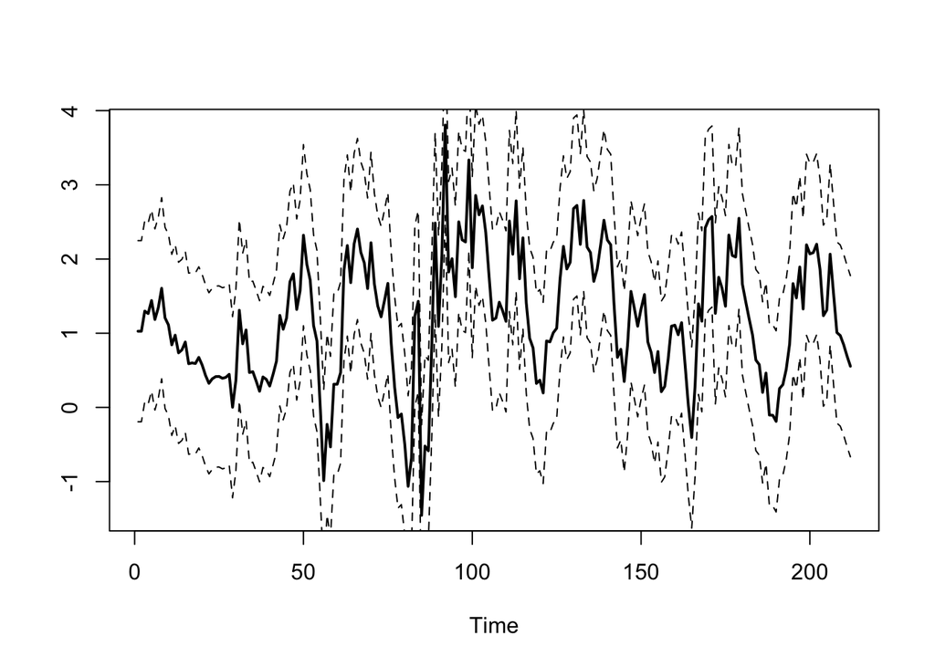

```r
high <- arch3Fit@fit$fitted.values + sqrt(var(arch3Fit@fit$fitted.values)*1.96)
low <- arch3Fit@fit$fitted.values - sqrt(var(arch3Fit@fit$fitted.values)*1.96)

graph_data <- arch3Fit@fit$fitted.values

plot.ts(graph_data, type = 'l', lty = 1, lwd = 2, xlab = "Time", ylab = " ")
lines(high, type="l", lty=2)
lines(low, type="l", lty=2)
```